# Fungal secondary metabolism determines aphid vector competence

This R markdown file contains R code used in the epidemiological modelling component of Simon et al. (2026) “Fungal secondary metabolism determines aphid vector competence”.

All figures in the paper can be produced using this file.

## Parameterisation of epidemiological model

Report the default parameterisation

```r
# parameters
defParamNIV <- list(K = 300,     # carrying capacity for spikes per unit area
                    mu = 0.1,    # rate of production of spikes
                    r = 0.15,    # aerial infection rate
                    Gamma = 1,   # time an aphid feeds for
                    alpha = 0.5, # probability aphid picks up fungus per visit
                    beta = 0.5,  # probability aphid transmits fungus per visit
                    v = 1.2,     # vector preference (fungus-free vectors to infected plants)
                    a = 0.5,     # aphid birth rate
                    eta = 0.2,   # rate of loss of infectivity
                    c = 0.2,     # death rate of aphids
                    M = 800,     # "carrying capacity" of aphids per unit area
                    delta = 1.5, # vector preference (fungus-carrying vectors to healthy plants)
                    # Severity parameters calculated by model fitting below
                    omega = 0.25,      # rate at which severity increases on a spike
                    zetaZero = 0.034)  # initial proportion of spikelets infected

defParamDON <- defParamNIV
# Three changes for DON relative to NIV:
#     - 1% as likely to pick up fungus from infected head as NIV
#     - 50% as likely to choose infected head as NIV
#     - 50% more transmissible via aerial spread
defParamDON$alpha <- 0.01 * defParamNIV$alpha
defParamDON$v <- 0.5 * defParamNIV$v
defParamDON$r <- 1.5 * defParamNIV$r
defParamDON$delta <- 1.0
```

## Figures

The following code generates the following figures (in order)

- Extended Data Figure 9. Panel (a)
- Extended Data Figure 9. Panel (b)
- Figure 4. Panel (f)
- Figure 4. Panel (g)
- Extended Data Figure 9. Panel (c)
- Extended Data Figure 9. Panel (d)
- Extended Data Figure 9. Panel (e)
- Extended Data Figure 9. Panel (f)

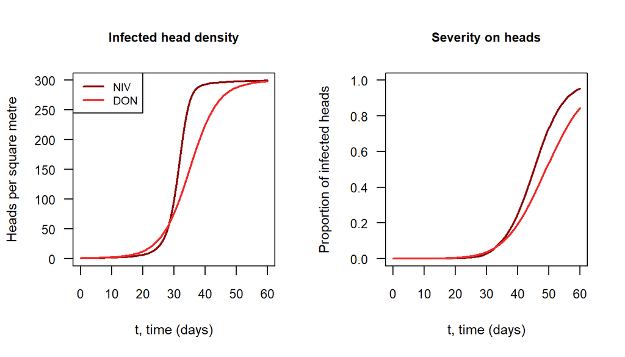

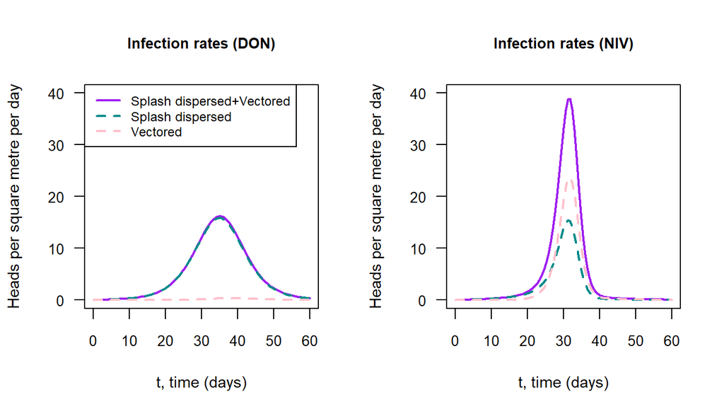

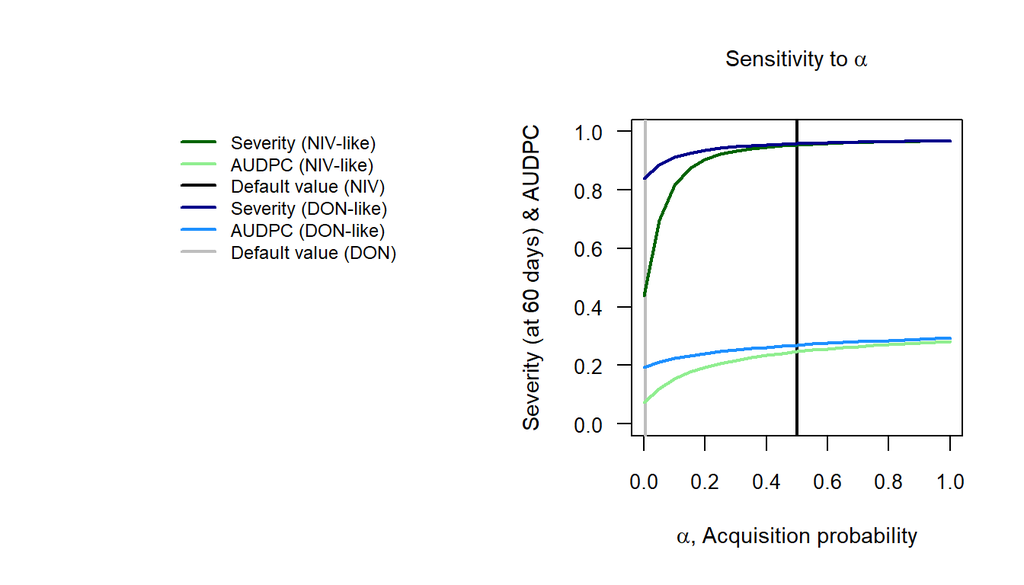

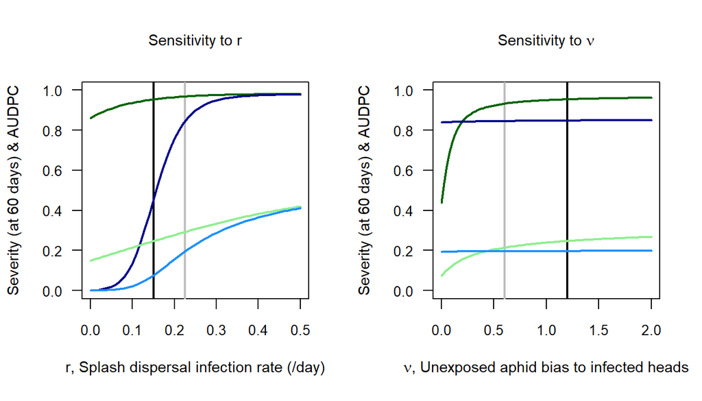

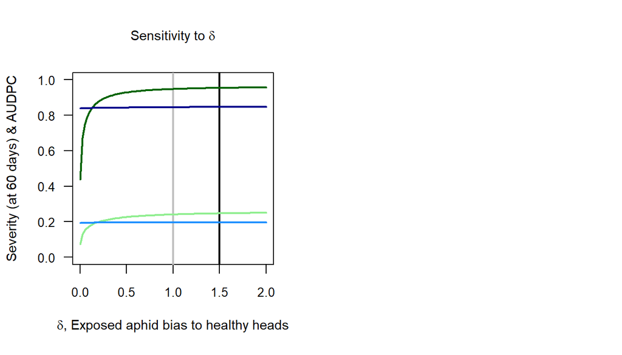

Find and report severity and AUPDC for default values with NIV and DON

```
## [1] "NIV: Sev = 0.953959863709781 AUDPC = 0.247187765464319"
```

```
## [1] "DON: Sev = 0.845319918376533 AUDPC = 0.196108322293595"
```

## Parameterising within-spike severity

The following code generates the following figures (in order)

- Extended Data Figure 9. Panel (g)
- Extended Data Figure 9. Panel (h)

The results of this code, i.e., the best fitting parameters

- $\zeta_0 = 0.034$ (severity at time of first infection)
- $\omega = 0.25$ day$^{-1}$ (rate of increase of severity).

are used in generating the figures above.

Note that for two samples in the data file used for fitting the logistic response (Within Head Severity Data.xlsx) the severity decreases between 11 and 13 days. These samples are filtered out before doing the fit.

```
## [1] "Filtered sample 34 since severity drops from 11 to 13 days"
## [1] "Filtered sample 45 since severity drops from 11 to 13 days"
```

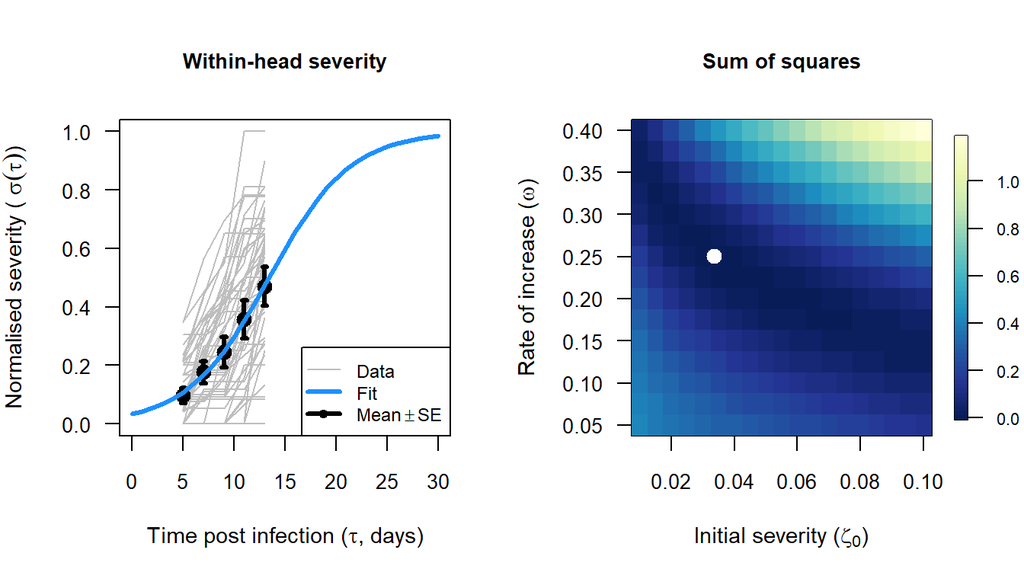

```
## $par
## [1] 0.03357973 0.25033898
##
## $value
## [1] 0.000259115
##
## $counts
## function gradient
##       61       NA
##
## $convergence
## [1] 0
##
## $message
## NULL
```

```
## [1] "Rounded to 2 significant figures, the best fitting parameters are:"
```

```
## [1] "Zeta0=0.034"
```

```
## [1] "Omega=0.25"
```